# UDAND_R-project

G.A.C.

2019-02-19

The dataset analyzed contains information about the chemical properties of a sample of almost 5000 white wines, with 11 different measurements and a ‘quality’ score for each observation. I will attempt to answer the following question:

## Which chemical properties make a white wine stand out?

### Skip to Final Plots and Summary

#### A quick look at the data

```
## [1] "NA values:"
```

```
## numeric(0)
```

```
## [1] "duplicate observations:"
```

```
## [1] 0
```

```
## [1] "structure of the data:"
```

```
## 'data.frame':    4898 obs. of  13 variables:
##  $ X                   : int  1 2 3 4 5 6 7 8 9 10 ...
##  $ fixed.acidity       : num  7 6.3 8.1 7.2 7.2 8.1 6.2 7 6.3 8.1 ...
##  $ volatile.acidity    : num  0.27 0.3 0.28 0.23 0.23 0.28 0.32 0.27 0.3 0.22 ...
##  $ citric.acid         : num  0.36 0.34 0.4 0.32 0.32 0.4 0.16 0.36 0.34 0.43 ...
##  $ residual.sugar      : num  20.7 1.6 6.9 8.5 8.5 6.9 7 20.7 1.6 1.5 ...
##  $ chlorides           : num  0.045 0.049 0.05 0.058 0.058 0.05 0.045 0.045 0.049 0.044 ...
##  $ free.sulfur.dioxide : num  45 14 30 47 47 30 30 45 14 28 ...
##  $ total.sulfur.dioxide: num  170 132 97 186 186 97 136 170 132 129 ...
##  $ density             : num  1.001 0.994 0.995 0.996 0.996 ...
##  $ pH                  : num  3 3.3 3.26 3.19 3.19 3.26 3.18 3 3.3 3.22 ...
##  $ sulphates           : num  0.45 0.49 0.44 0.4 0.4 0.44 0.47 0.45 0.49 0.45 ...
##  $ alcohol             : num  8.8 9.5 10.1 9.9 9.9 10.1 9.6 8.8 9.5 11 ...
##  $ quality             : int  6 6 6 6 6 6 6 6 6 6 ...
```

It looks like there are no missing or duplicate values. The variable *X* identifies each sample of wine. The variable *quality* is the dependent variable that I will try to explain with all the other variables showing chemical properties of each wine.

### Univariate analysis

I want to see a summary of the *quality* variable first:

```
##    Min. 1st Qu.  Median    Mean 3rd Qu.    Max.
##   3.000   5.000   6.000   5.878   6.000   9.000
```

```
##
##    3    4    5    6    7    8    9
##   20  163 1457 2198  880  175    5
```

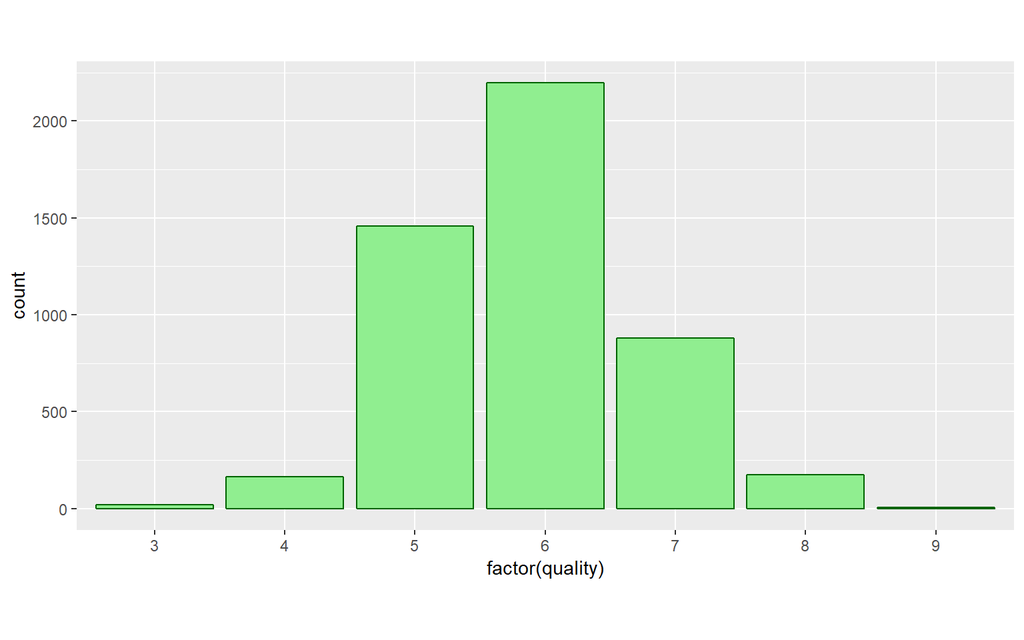

The distribution is ‘normal’ shaped; the ratings are evenly distributed with the mean value being very close to the median.

Next I will look at the distribution of the chemical properties that a person without any deep knowledge about wine or chemistry might feel more familiar with, looking at the most common values and the variablity in this sample: *alcohol* content (measured in percentage of volume) and *residual sugar* (measured in [grams per litre](https://en.wikipedia.org/wiki/Sweetness_of_wine#Residual_sugar)) .

I also want to look at the values of *density* and *pH* compared to those of water (at room temperature, around [0.998 grams per mililitre](https://en.wikipedia.org/wiki/Density#Water) and a [pH of 7.0](https://en.wikipedia.org/wiki/PH)).

I will use blue color to mark the inter-quartile range for each variable: the middle 50% of values between the bottom 25% and the top 25% of all observations ordered by said variable.

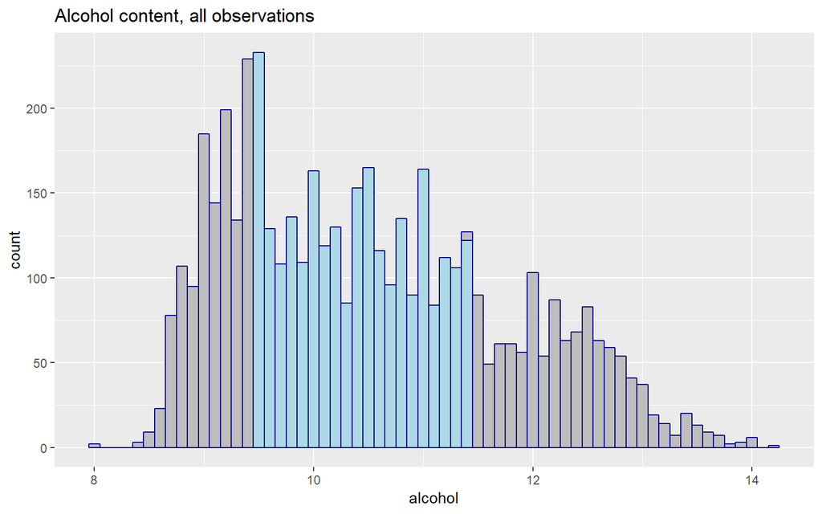

```
##    Min. 1st Qu.  Median    Mean 3rd Qu.    Max.
##    8.00    9.50   10.40   10.51   11.40   14.20
```

The middle 50% of the wines in the sample have an alcohol content between 9.5% and 11.4%. The minimum and maximum values are 8.0% and 14.2% and the distribution is fairly even although there is somewhat of a right skew with the highest values ranging further past the third quartile than the lowest values extend between the first quartile and the minimum.

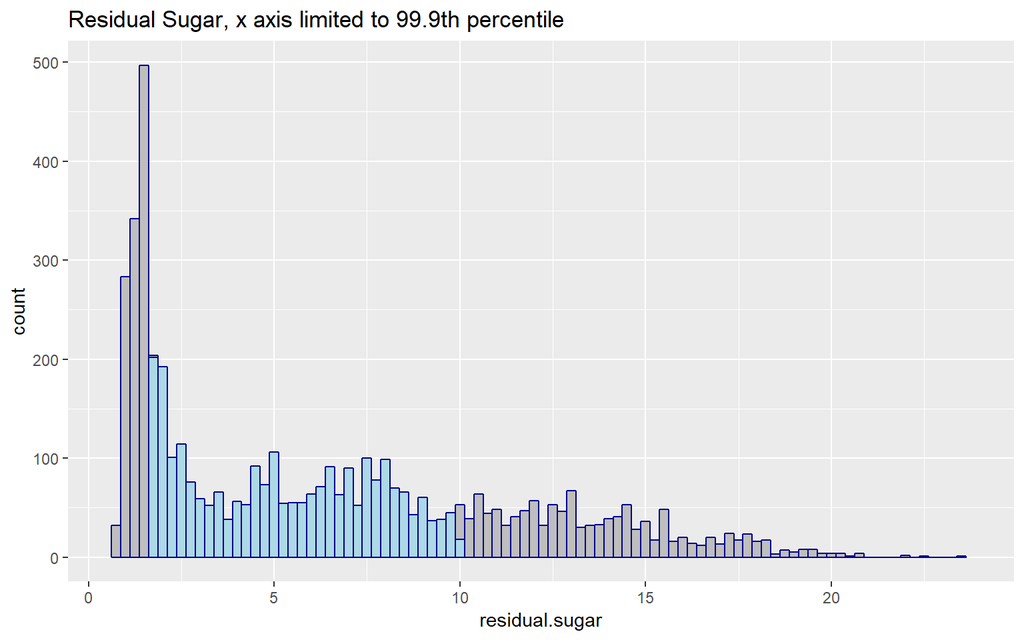

```
##    Min. 1st Qu.  Median    Mean 3rd Qu.    Max.
##   0.600   1.700   5.200   6.391   9.900  65.800
```

In the case of residual sugar the range of values found in the sample is much wider and the distribution is very skewed to the right. The bulk of the distribution ranges from concentrations of about one gram per litre to values over ten times higher, and there are ouliers up to more than 60 grams per litre that make an x axis limit necessary. Before seeing any correlation, the high variability in this chemical property suggests that I should not expect it to have a big impact on the quality of a white wine.

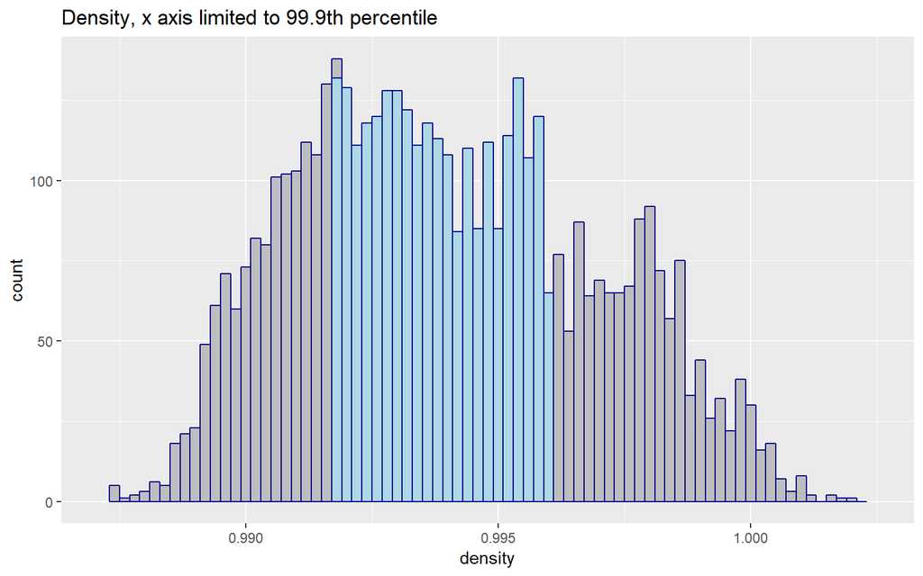

```
##    Min. 1st Qu.  Median    Mean 3rd Qu.    Max.
##  0.9871  0.9917  0.9937  0.9940  0.9961  1.0390
```

The density of white wine is very similar to that of water and there is little variability in the values found. There seem to be some outliers but the distribution is otherwise normal shaped.

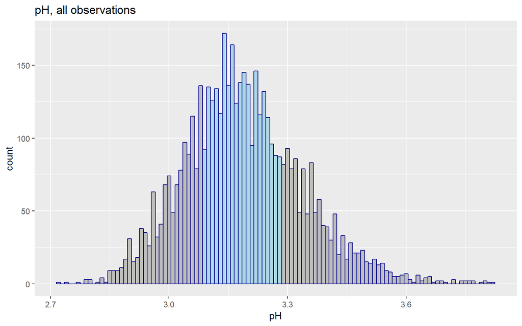

```
##    Min. 1st Qu.  Median    Mean 3rd Qu.    Max.
##   2.720   3.090   3.180   3.188   3.280   3.820
```

White wine is very acidic compared to water and its pH follows a normal distribution that doesn’t appear to indicate big variability. Still, considering the logarithmic nature of pH it seems that wines at one end of the distribution might be much more acidic than those at the other end, so I would need to look at the correlation with quality to really know if pH is determinant.

I decide to make three bins for the *quality* variable and see if I find any patterns that can answer the question raised earlier:

**Which chemical properties make a white wine stand out?**

##### Response variable bins

First I decide the *quality* scores to divide at, and check that the amount of observations in each bin is suitable for my purposes:

```
##
## <=5: below average         6: average >=7: above average
##               1640               2198               1060
```

Then I set a color scale and make a barplot of the new *quality* bins:

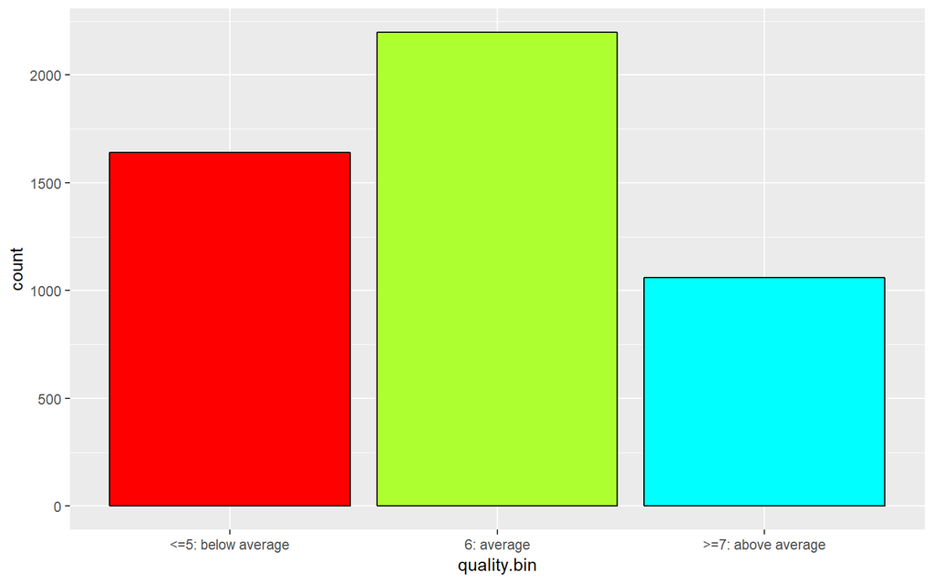

The dividing values I set for the quality bins split the observations fairly evenly. This is important for any conclusions to be meaningful, as I do not look for common features of only a tiny minority of the observations.

### Bivariate analysis

#### Finding the most relevant variables

In order to focus on the more interesting chemical properties, I want to look at the correlations with *quality*. That way I can choose only a few variables to analyze further.

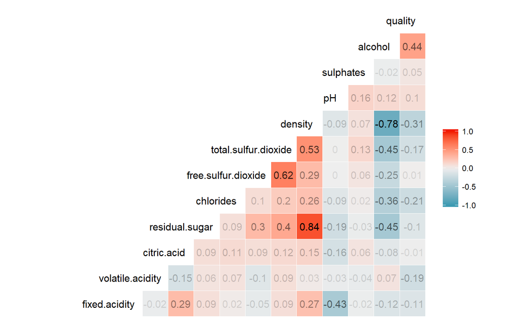

The results are **not promising: the strongest correlation with *quality*** **is in the variable *alcohol*, with a correlation coefficient of 0.44**. **Of the other variables** with correlation coefficients with *quality* at least **close to $\pm0.2$, only *volatile acidity* does not show a stronger** **correlation of the same sign with *alcohol***.

As I ventured earlier, the highly variable *residual sugar* has a very low correlation with quality. The effect of *pH* is equally low.

#### Explanatory variable Box Plots

I make box plots divided by quality bin for each of the explanatory variables that have a correlation coefficient with *quality* of at least close to $\pm0.2$: *alcohol* (.44), *volatile acidity* (-.19), *density* (-.31), *chlorides* (-.21) and *total sulfur dioxide* (-.17).

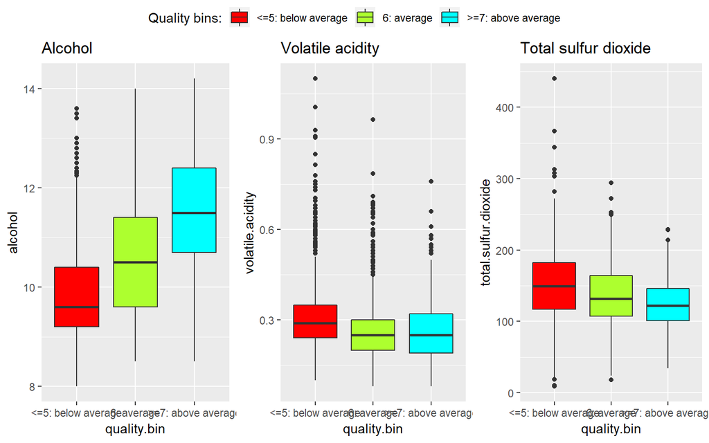

Not all the visible trends are strong, however it is possible to see in these plots how, for example, of the wines rated ‘below average’, less than 25% (only those sitting above the higher bound of the IQR -the red box in this case) reach or exceed the same *alcohol* value that is surpassed by more than 75% of the wines rated ‘above average’ (since the lower end of the blue box -the first quartile of ‘above average’ wines- lies above the same *alcohol* value).

One can look at the median values and IQRs of the different quality bins for each chemical property to get an idea of the variable’s influence on quality.

##### Dealing with outliers

When outliers are present, limiting the axes to a certain percentile, for example leaving out the highest 1% of values for the variable, can help zoom in on the patterns shown by the plot. If I were to instead subset the data used for the plot, that would cause slight changes in the measures of median, IQR and so on.

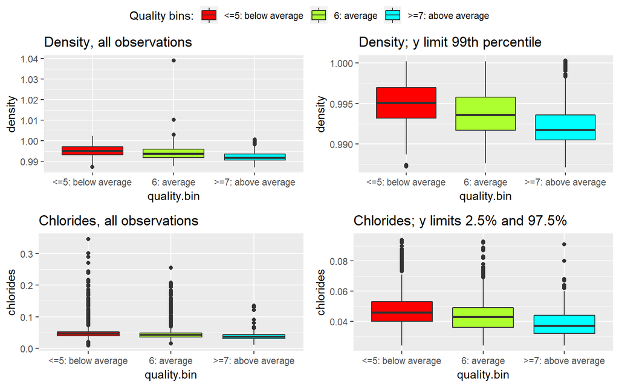

#### Explanatory variable Histograms

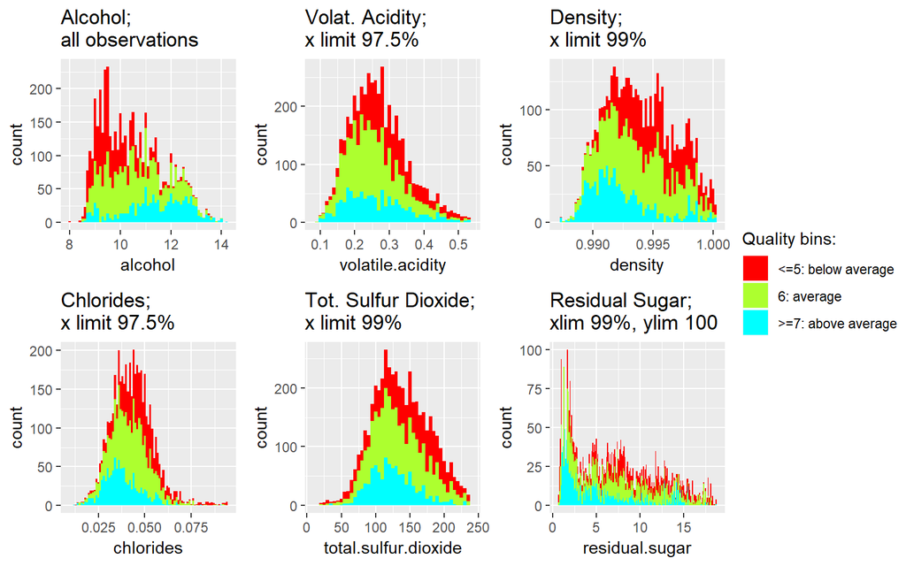

Similarly to the box plots, these histograms hint that past a certain threshold of each of these variables there seems to be a higher likelihood of the wine in question being ‘below average’, instead of ‘average’ or above in quality. It is difficult to make the same observation about the residual sugar histogram on the bottom right corner.

##### Explanatory variable bins

It may be interesting to bin each of these variables for more clarity in later plots. I write a function **exvr.bin** using the function **cut** to bin values as low, medium or high dividing them at the 33rd and 67th percentiles, so that I can more easily bin all the explanatory variables:

```r
exvr.bin = function(x) cut(x, c(min(x), quantile(x, 0.333), quantile(x, 0.667),
    max(x)), include.lowest = TRUE, labels = c("Bottom 33%", "Middle 33%", "Top 33%"),
    ordered_result = TRUE)

# I can then pipe each column to my function and save time and possible
# typos:
wwine$alcohol.bin <- wwine$alcohol %>% exvr.bin()
```

### Multivariate analysis

The truly interesting patterns should become visible when combining several variables.

#### Linear Model

I will first try to make a linear model to more clearly see which variables are useful for explaining *quality*.

First I combine alcohol (which has the strongest correlation with quality) with the other variables separately.

```
##
## Calls:
## m1: lm(formula = quality ~ alcohol, data = wwine)
## m2: lm(formula = quality ~ alcohol + volatile.acidity, data = wwine)
## m3: lm(formula = quality ~ alcohol + density, data = wwine)
## m4: lm(formula = quality ~ alcohol + total.sulfur.dioxide, data = wwine)
## m5: lm(formula = quality ~ alcohol + chlorides, data = wwine)
##
## ==============================================================================================
##                              m1            m2            m3            m4            m5
## ----------------------------------------------------------------------------------------------
##   (Intercept)               2.582***      3.017***    -22.492***      2.419***      2.861***
##                            (0.098)       (0.098)       (6.165)       (0.133)       (0.116)
##   alcohol                   0.313***      0.324***      0.360***      0.322***      0.298***
##                            (0.009)       (0.009)       (0.015)       (0.010)       (0.010)
##   volatile.acidity                       -1.979***
##                                          (0.110)
##   density                                              24.728***
##                                                        (6.079)
##   total.sulfur.dioxide                                                0.001
##                                                                      (0.000)
##   chlorides                                                                        -2.471***
##                                                                                    (0.558)
## ----------------------------------------------------------------------------------------------
##   R-squared                 0.190         0.240         0.192         0.190         0.193
##   adj. R-squared            0.190         0.240         0.192         0.190         0.193
##   sigma                     0.797         0.772         0.796         0.797         0.796
##   F                      1146.395       773.875       583.290       575.100       585.182
##   p                         0.000         0.000         0.000         0.000         0.000
##   Log-likelihood        -5839.391     -5681.776     -5831.127     -5837.755     -5829.599
##   Deviance               3112.257      2918.264      3101.773      3110.178      3099.838
##   AIC                   11684.782     11371.552     11670.255     11683.510     11667.199
##   BIC                   11704.272     11397.538     11696.241     11709.496     11693.185
##   N                      4898          4898          4898          4898          4898
## ==============================================================================================
```

From the R-squared values I see that the only truly useful variables are *alcohol* and [*volatile acidity*](https://extension.psu.edu/volatile-acidity-in-wine).

```
##
## Calls:
## m6: lm(formula = quality ~ alcohol + volatile.acidity + density,
##     data = wwine)
## m7: lm(formula = quality ~ alcohol + volatile.acidity + total.sulfur.dioxide,
##     data = wwine)
## m8: lm(formula = quality ~ alcohol + volatile.acidity + chlorides,
##     data = wwine)
## m9: lm(formula = quality ~ alcohol + volatile.acidity + density +
##     total.sulfur.dioxide, data = wwine)
## m10: lm(formula = quality ~ alcohol + volatile.acidity + density +
##     total.sulfur.dioxide + chlorides, data = wwine)
##
## ==============================================================================================
##                              m6            m7            m8            m9           m10
## ----------------------------------------------------------------------------------------------
##   (Intercept)             -36.499***      2.649***      3.179***    -31.975***    -30.759***
##                            (6.001)       (0.129)       (0.114)       (6.280)       (6.295)
##   alcohol                   0.399***      0.344***      0.315***      0.402***      0.391***
##                            (0.014)       (0.010)       (0.010)       (0.014)       (0.015)
##   volatile.acidity         -2.072***     -2.044***     -1.948***     -2.099***     -2.070***
##                            (0.110)       (0.111)       (0.110)       (0.111)       (0.111)
##   density                  38.992***                                 34.315***     33.251***
##                            (5.920)                                   (6.223)       (6.234)
##   total.sulfur.dioxide                    0.001***                    0.001*        0.001*
##                                          (0.000)                     (0.000)       (0.000)
##   chlorides                                            -1.491**                    -1.370*
##                                                        (0.544)                     (0.543)
## ----------------------------------------------------------------------------------------------
##   R-squared                 0.247         0.243         0.241         0.248         0.249
##   adj. R-squared            0.246         0.243         0.241         0.247         0.248
##   sigma                     0.769         0.771         0.772         0.768         0.768
##   F                       534.843       524.058       519.107       403.007       324.034
##   p                         0.000         0.000         0.000         0.000         0.000
##   Log-likelihood        -5660.164     -5672.388     -5678.019     -5657.216     -5654.027
##   Deviance               2892.625      2907.099      2913.791      2889.144      2885.385
##   AIC                   11330.329     11354.776     11366.039     11326.431     11322.054
##   BIC                   11362.812     11387.259     11398.522     11365.411     11367.530
##   N                      4898          4898          4898          4898          4898
## ==============================================================================================
```

This second attempt tells me that keeping *density* might have some value, but I will most likely discard total sulfur dioxide and *chlorides* because adding them would hardly improve the model (meaning they would only add noise to a visualization).

#### Scatterplots

With the information from the R-squared values of the linear model I can now test whether the variables I chose actually add clarity to a visualization.

I want to see scatterplots of the different variables against Quality, and I can add layers for the bins I made as color and shape. More variables could be added as size of the points, but this is likely to worsen overplotting especially given the non-continuous Quality variable and the low correlations that will not make for clearly separate groups but rather a messy mix of whatever distinct levels I set.

Since color differences will be the easiest to distinguish, following the results of the linear model I will **compare the effect of adding to Alcohol (as x) and** **Volatile Acidity (as shape) a layer of color determined by the properties of** **Density, Chlorides or Total Sulfur Dioxide**. To maximize clarity I will use bins instead of the original continuous values for all explanatory variables other than Alcohol.

Note: jitter has been added to the points to mitigate the overplotting caused by the discrete quality scores. Because of this jitter effect, the points corresponding to observations in the intersection of a certain quality score and alcohol content will not appear in exactly the same positions in the y axis in the different scatterplots.

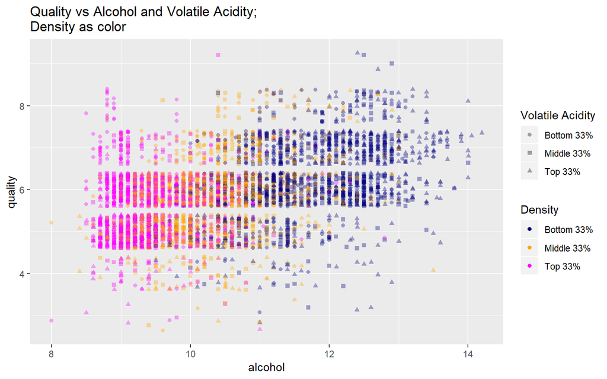

The distribution of the points hints the positive correlation between alcohol and quality. I can tell from this first plot that *density* is strongly inversely correlated with alcohol, but appears to have very little effect of its own on quality. If the shape layer reveals anything, it is that high quality wines with high volatile acidity are almost all high in alcohol.

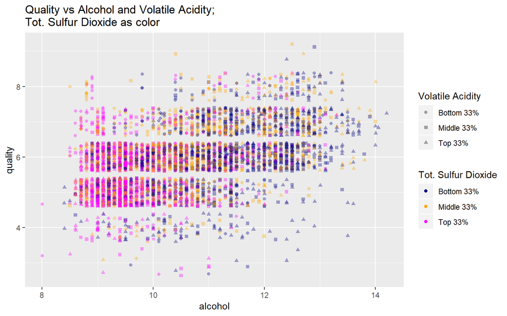

Adding *total sulfur dioxide* as a color layer only shows that it is correlated with alcohol, just in a weaker way than density. This variable is of no use in explaining quality.

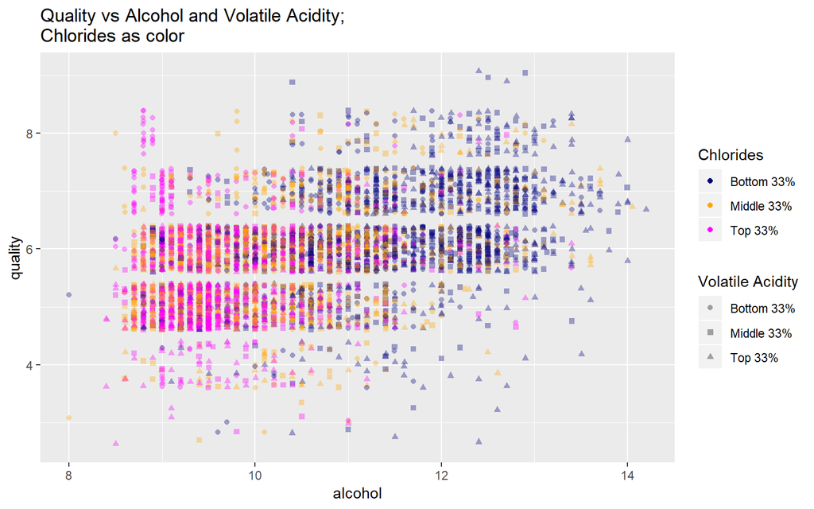

Similarly to the previous plot, a negative correlation between Alcohol and Chlorides is apparent, however the three levels of the Chlorides color layer can be found in similar proportions in every level of Quality. This variable does not add much value to the visualization.

After seeing the linear model’s R-squared values and the color layers in these scatterplots, I decide to leave out the three variables and focus only on *alcohol* and *volatile acidity* for my final plots and conclusions.

## Final Plots and Summary

The attempt to make a linear model makes me decide to focus on the the two variables *alcohol* and *volatile.acidity* as explanatory variables for *quality* of the white wine observations, as they seem to be the only ones from which some meaning can be reliably extracted.

#### **Observation counts at each quality score colored by bins of main variables**

The bar plots below show **how many of the observed white wines fall into** **each discrete quality score**, and then look at this distribution separately to show **what relative values of the most relevant chemical** **properties** (bottom, middle and top third of measured values for each) **make up each quality score**.

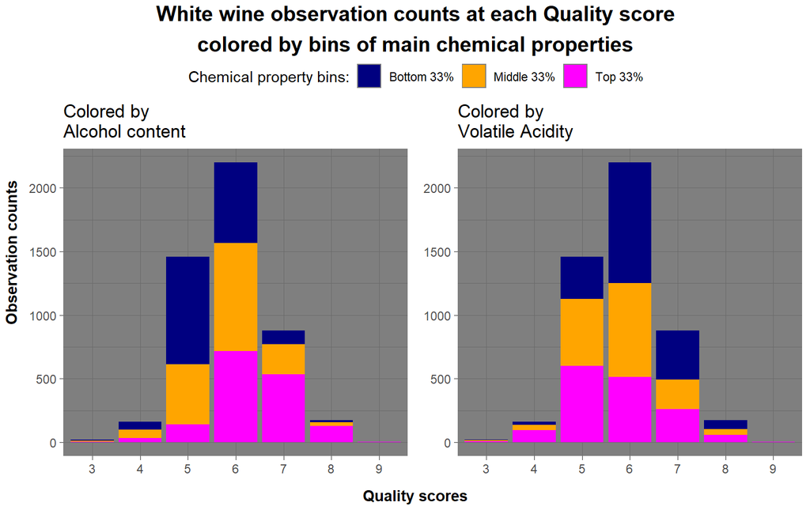

Besides showing what scores are most common, the bar plots show that most wines rated 5 or worse are relatively low in alcohol while those rated 7 or better are mostly high in alcohol content, or that relatively low volatile acidity is much less frequent in wines rated 5 or worse than in better rated ones.

#### **Distribution of main explanatory variables divided by quality bin**

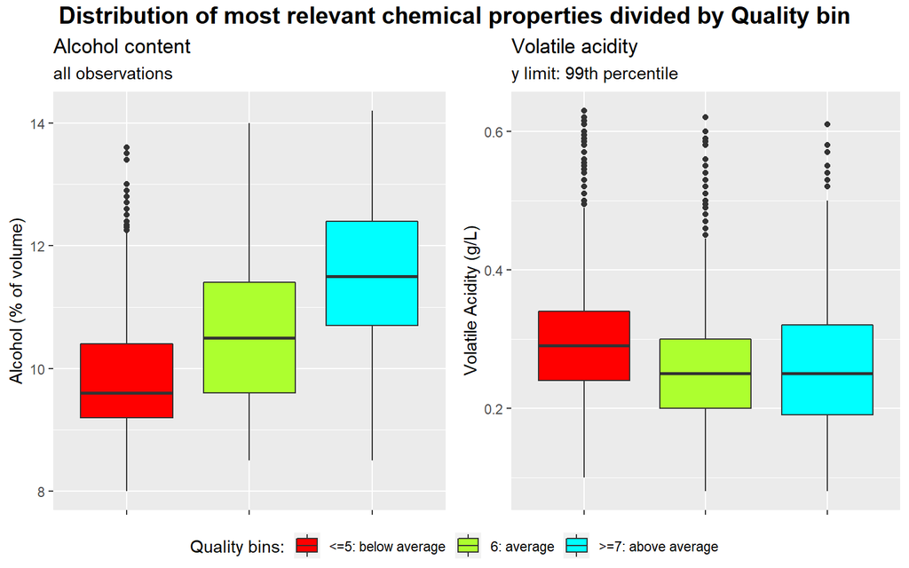

The box plots show graphically how only about a quarter of white wines rated 7 or above in Quality have an alcohol content under 11%, while the majority of ‘average’ wines and most of the ‘below average’ wines have a lower alcohol content. Similarly, a value of Volatile Acidity above 0.3 grams per litre makes a white wine more likely to be rated ‘below average’, although in the case of this chemical property wines of quality ‘average’ and ‘above average’ do not seem to differ from each other and there are ouliers in all quality groups; variability in Volatile Acidity is more acceptable than in Alcohol.

#### **Quality score explained by main variables**

The scatterplot below can help in visualizing the patterns identified throghout the analysis.

I plot the continuous values of Alcohol in the x axis because this variable has the strongest correlation with quality and thus shows the most clear shape.

I represent the three levels of binned values of Volatile Acidity with a color scale because this is the only other variable with some effect on quality that is not correlated with Alcohol.

I leave out other variables given their very small influence on quality (as measured and visualized in the Multivariate Analysis section) and because their potential to distract the viewer from other patterns is greater than the value of the information that they could add to the plot.

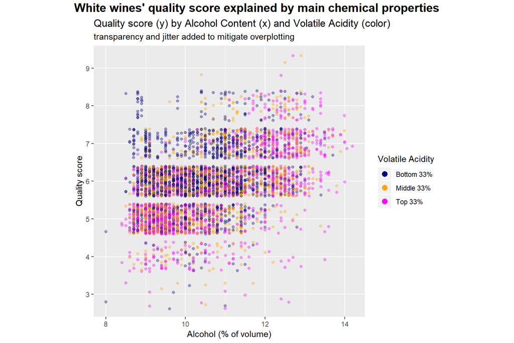

Despite the low correlations in the data, this plot can help see that the ‘above average’ wines with low alcohol content have low acidity in most cases, and most of the highly rated wines with high acidity are also high in alcohol content.

White wines rated ‘average’ are a mixed bag, however among those rated 5 or worse a low volatile acidity is clearly less common.

While some patterns are identifiable, the lack of more clear correlations suggests that other variables not measured in the available data play an important role in determining the quality score of a particular white wine.

## Reflections

While a conclusion can be extracted that **the most reliable predictors for** **a white wine being rated highly** (or at least not being rated poorly) **are first a relatively high alcohol content, and second a** **relatively low volatile acidity**, there are many observations in the data that do not match these conditions.

This suggests that **other variables that have not been accounted for** in the available data **may have an important impact on the quality rating**. Relevant data other than the chemical measurements available could be the temperature of each wine when rated or the time since production.

The main difficulty in performing this analysis was the lack of significant correlations between the response variable and the available explanatory variables.

Attempting to make a linear model provided valuable insight into which of the variables were of less relevance, in a way that may be more clear than just looking at the correlations and plots.

Given these conditions, binning the different variables and then combining them in multivariate visualizations was useful for seeing the patters present. Perhaps more detailed binning of the variables and more zoomed-in visualizations to limit the noise could help extract more precise conclusions.